# John.RMD

John Ivanov

2022-07-25

## Scatter plot matrix of question data

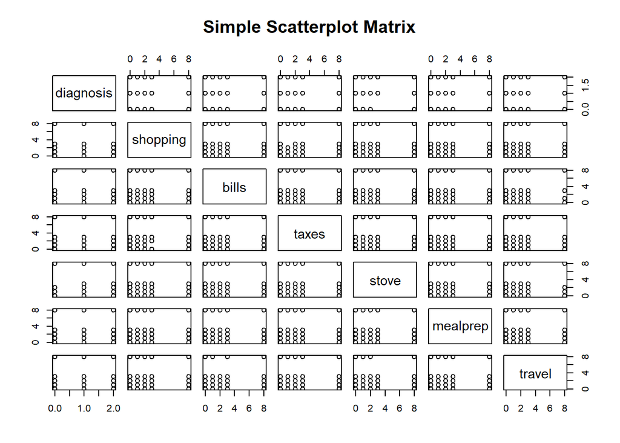

## Barplots relating diagnosis with certain question variables

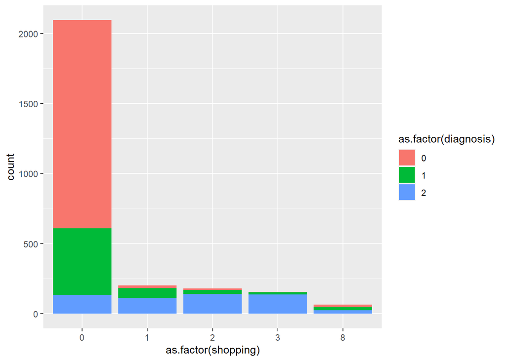

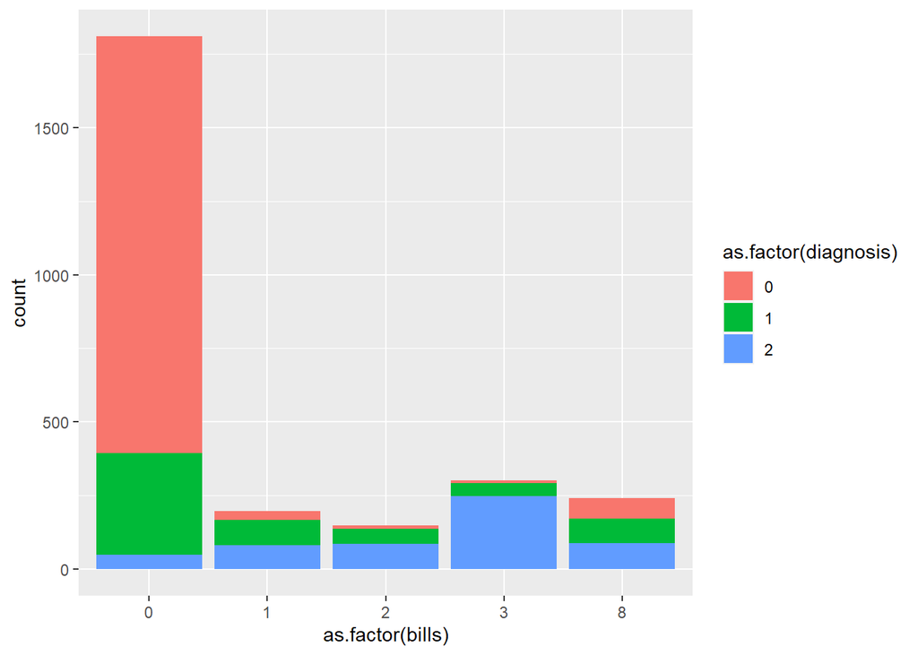

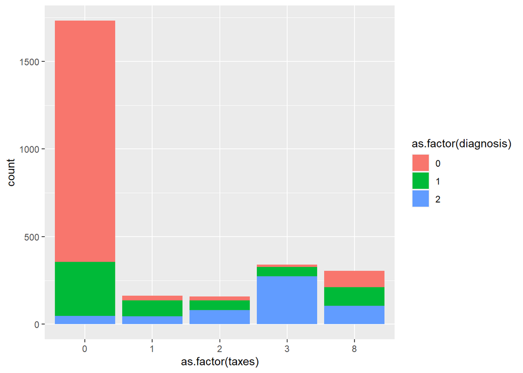

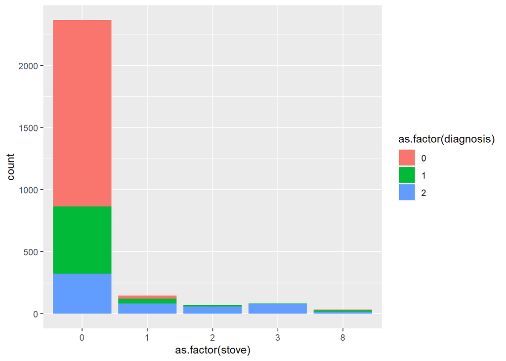

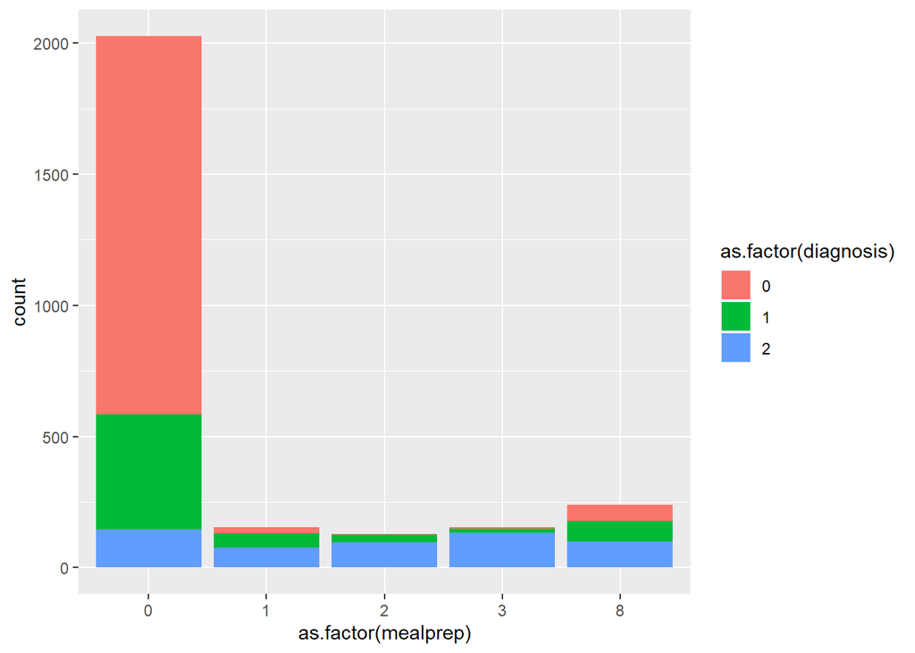

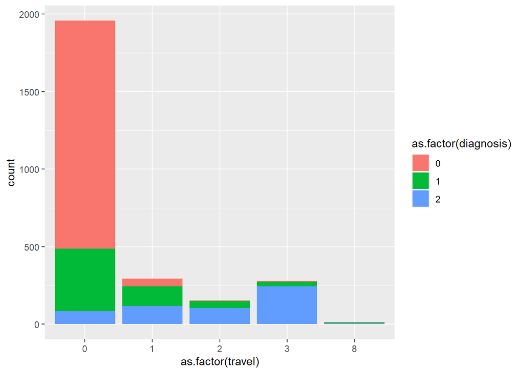

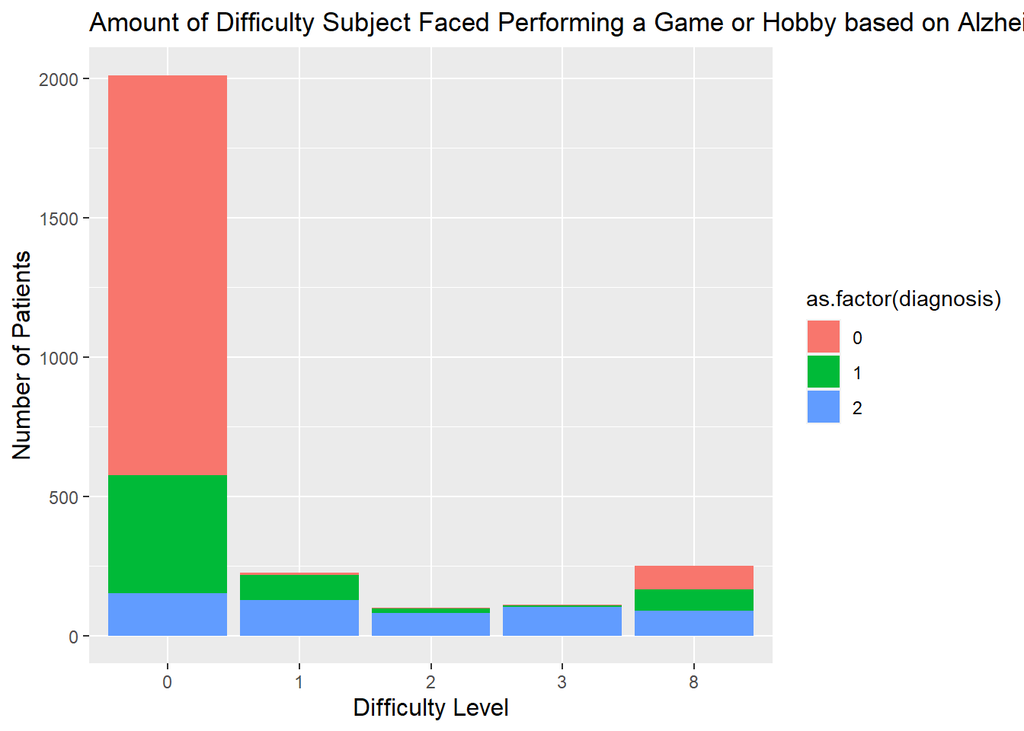

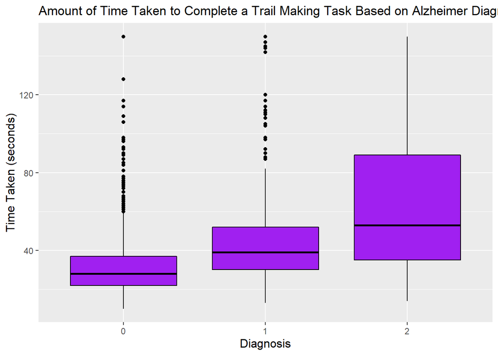

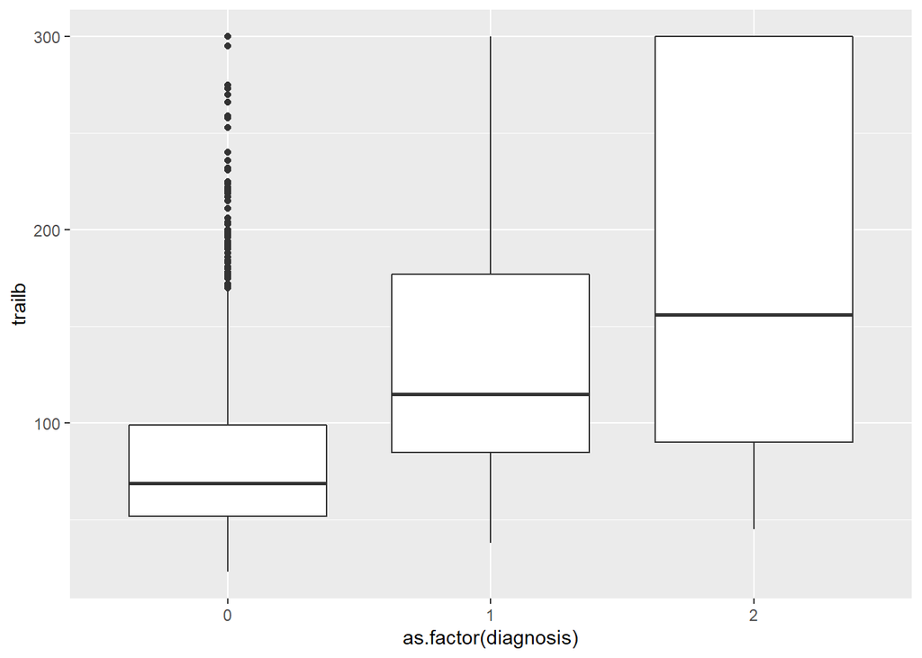

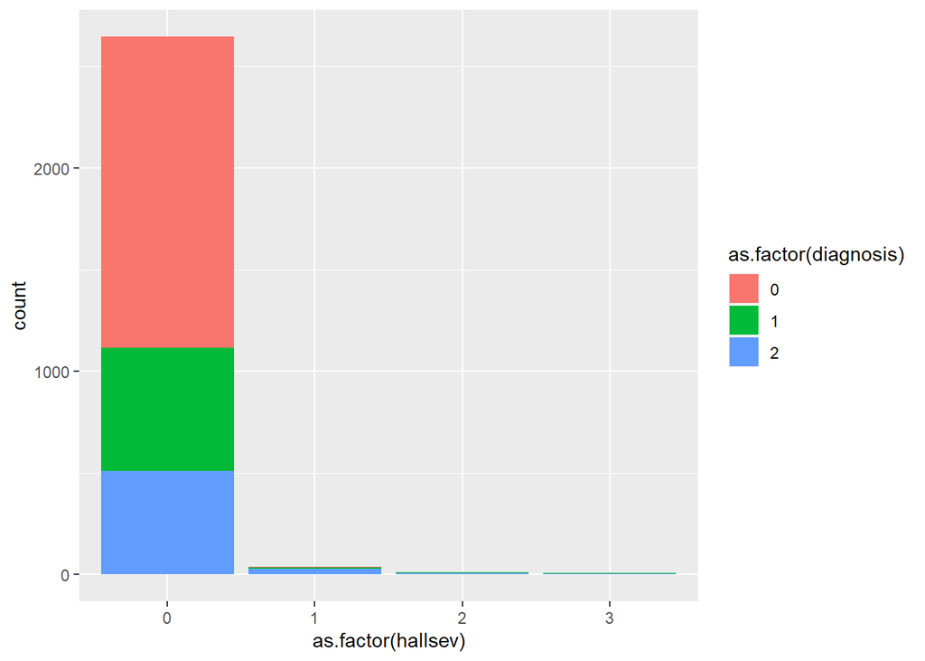

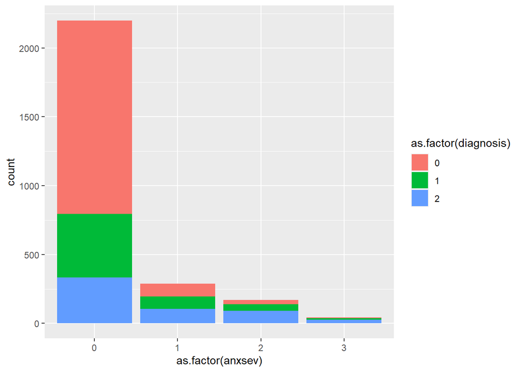

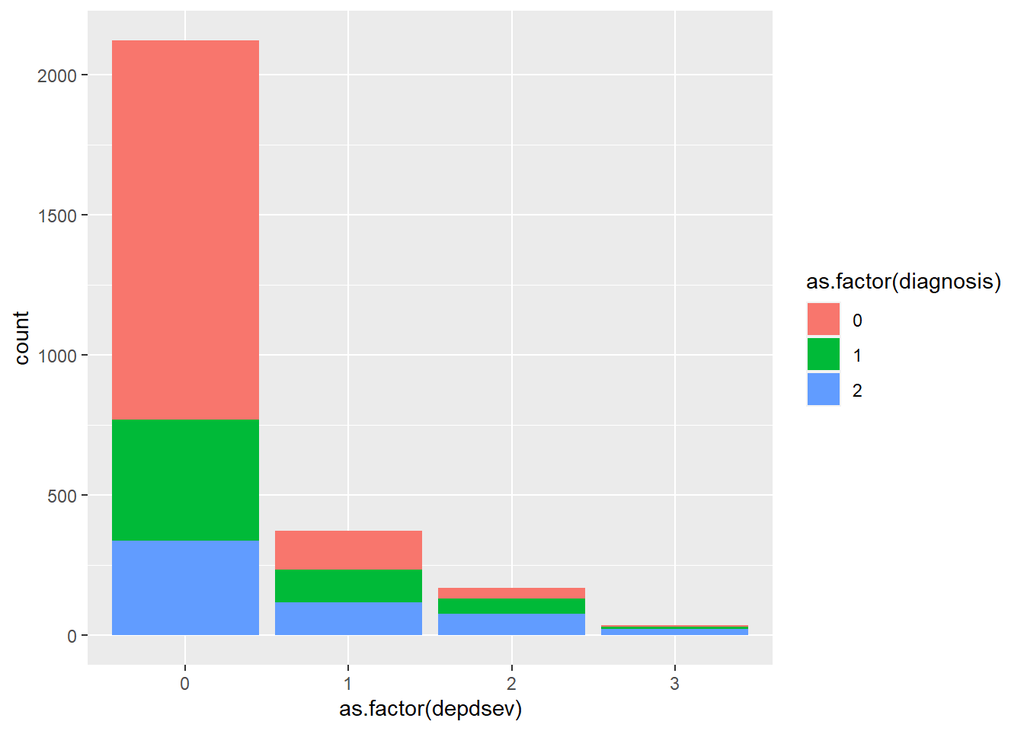

[5 more figures not shown]

## Chi-Squared Test for each question variable

```
##
##  Pearson's Chi-squared test
##
## data:  shop_table
## X-squared = 1341.4, df = 8, p-value < 2.2e-16
```

Because the p-value, 2.6568108^{-284}, is less than 0.05, we can conclude that there is a relationship between shopping and diagnosis.

```
##
##  Pearson's Chi-squared test
##
## data:  bills_table
## X-squared = 1546.4, df = 8, p-value < 2.2e-16
```

Because the p-value, 0, is less than 0.05, we can conclude that there is a relationship between bills and diagnosis.

```
##
##  Pearson's Chi-squared test
##
## data:  taxes_table
## X-squared = 1554, df = 8, p-value < 2.2e-16
```

Because the p-value, 0, is less than 0.05, we can conclude that there is a relationship between taxes and diagnosis.

```
##
##  Pearson's Chi-squared test
##
## data:  stove_table
## X-squared = 662.04, df = 8, p-value < 2.2e-16
```

Because the p-value, 1.0575075^{-137}, is less than 0.05, we can conclude that there is a relationship between stove and diagnosis.

```
##
##  Pearson's Chi-squared test
##
## data:  meal_table
## X-squared = 1154.1, df = 8, p-value < 2.2e-16
```

Because the p-value, 8.0009423^{-244}, is less than 0.05, we can conclude that there is a relationship between meal and diagnosis.

```
##
##  Pearson's Chi-squared test
##
## data:  travel_table
## X-squared = 1579.8, df = 8, p-value < 2.2e-16
```

Because the p-value, 0, is less than 0.05, we can conclude that there is a relationship between travel and diagnosis.

```
##
##  Pearson's Chi-squared test
##
## data:  chess_table
## X-squared = 1163.2, df = 8, p-value < 2.2e-16
```

Because the p-value, 8.6809623^{-246}, is less than 0.05, we can conclude that there is a relationship between chess and diagnosis.

```
##
##  Welch Two Sample t-test
##
## data:  traila by bin_diag
## t = -22.364, df = 1496.2, p-value < 2.2e-16
## alternative hypothesis: true difference in means between group 0 and group 1 is not equal to 0
## 95 percent confidence interval:
##  -26.63274 -22.33749
## sample estimates:
## mean in group 0 mean in group 1
##        31.74902        56.23413
```

Because the p-value, 8.3093066^{-96}, is less than 0.05, we can conclude that there is a relationship between trialA and diagnosis.

```
##
##  Welch Two Sample t-test
##
## data:  trailb by bin_diag
## t = -27.81, df = 1672.9, p-value < 2.2e-16
## alternative hypothesis: true difference in means between group 0 and group 1 is not equal to 0
## 95 percent confidence interval:
##  -84.08076 -73.00202
## sample estimates:
## mean in group 0 mean in group 1
##        82.85398       161.39537
```

Because the p-value, 3.11333^{-140}, is less than 0.05, we can conclude that there is a relationship between trailB and diagnosis.

```
##
##  Pearson's Chi-squared test
##
## data:  hall_table
## X-squared = 128.67, df = 6, p-value < 2.2e-16
```

Because the p-value, 2.4534649^{-25}, is less than 0.05, we can conclude that there is a relationship between hallucinations and diagnosis.

```
##
##  Pearson's Chi-squared test
##
## data:  anx_table
## X-squared = 305.08, df = 6, p-value < 2.2e-16
```

Because the p-value, 6.6851859^{-63}, is less than 0.05, we can conclude that there is a relationship between anxiety and diagnosis.

```
##
##  Pearson's Chi-squared test
##
## data:  depress_table
## X-squared = 237.69, df = 6, p-value < 2.2e-16
```

Because the p-value, 1.7473918^{-48}, is less than 0.05, we can conclude that there is a relationship between depression and diagnosis.

```
##
##  Pearson's Chi-squared test
##
## data:  gend_table
## X-squared = 96.346, df = 2, p-value < 2.2e-16
```

Because the p-value, 1.1988047^{-21}, is less than 0.05, we can conclude that there is a relationship between gender and diagnosis.

```
##
##  Welch Two Sample t-test
##
## data:  weight by bin_diag
## t = 3.3197, df = 2562.9, p-value = 0.0009138
## alternative hypothesis: true difference in means between group 0 and group 1 is not equal to 0
## 95 percent confidence interval:
##  1.87343 7.28060
## sample estimates:
## mean in group 0 mean in group 1
##        169.2451        164.6681
```

Because the p-value, 9.1384227^{-4}, is less than 0.05, we can conclude that there is a relationship between weight and diagnosis.

```
##
##  Welch Two Sample t-test
##
## data:  hrate by bin_diag
## t = -0.79623, df = 2380.6, p-value = 0.426
## alternative hypothesis: true difference in means between group 0 and group 1 is not equal to 0
## 95 percent confidence interval:
##  -1.1694074  0.4939996
## sample estimates:
## mean in group 0 mean in group 1
##        66.98305        67.32075
```

```
##
##  Welch Two Sample t-test
##
## data:  bpsys by bin_diag
## t = -3.9511, df = 2380.6, p-value = 8.005e-05
## alternative hypothesis: true difference in means between group 0 and group 1 is not equal to 0
## 95 percent confidence interval:
##  -4.311324 -1.451296
## sample estimates:
## mean in group 0 mean in group 1
##        131.2027        134.0840
```

Because the p-value, 8.0054247^{-5}, is less than 0.05, we can conclude that there is a relationship between blood pressure and diagnosis.

```
##
##  Pearson's Chi-squared test
##
## data:  motor_table
## X-squared = 281.95, df = 6, p-value < 2.2e-16
```

Because the p-value, 6.0108697^{-58}, is less than 0.05, we can conclude that there is a relationship between motor disturbance and diagnosis.